# R 期中競賽 第三組

### 準備資料

```r
#Loading multiple .csv files as separate data frames
getwd()
folder <- "data/"
file_list <- list.files(path = folder, pattern = "*.csv")
```

```r
#Read in each .csv file
for (i in 1:length(file_list)){
  assign(file_list[i],
         read.csv(paste(folder,file_list[i],sep=''),stringsAsFactors = F)
  )}
```

```r
#Rename data
geo <- olist_geolocation_dataset.csv
orders <- olist_orders_dataset.csv
cust <- olist_customers_dataset.csv
sellers <- olist_sellers_dataset.csv
products <- olist_products_dataset.csv
orderitems <- olist_order_items_dataset.csv
payments <- olist_order_payments_dataset.csv
nametrans <- product_category_name_translation.csv
reviews <- olist_order_reviews_dataset.csv
closed <- olist_closed_deals_dataset.csv
marketing <- olist_marketing_qualified_leads_dataset.csv
```

- 讀取所有資料，包含所有行銷資料。

```r
# 地理資料整理
geo$geolocation_lat<-round(geo$geolocation_lat,3)
geo$geolocation_lng<-round(geo$geolocation_lng,3)

selllocation<-geo %>% group_by(geolocation_city) %>% summarise(selllat = max(geolocation_lat),selllng=max(geolocation_lng))
custlocation<-geo %>% group_by(geolocation_city) %>% summarise(custlat = max(geolocation_lat),custlng=max(geolocation_lng))
```

```r
# 時間資料處理
orders$order_approved_at<-as.Date(orders$order_approved_at,format="%Y-%m-%d %H:%M:%S")
orders$order_purchase_timestamp<-as.Date(orders$order_purchase_timestamp,format="%Y-%m-%d %H:%M:%S")
orders$order_delivered_carrier_date<-as.Date(orders$order_delivered_carrier_date,format="%Y-%m-%d %H:%M:%S")
orders$order_delivered_customer_date<-as.Date(orders$order_delivered_customer_date,format="%Y-%m-%d %H:%M:%S")
orders$order_estimated_delivery_date<-as.Date(orders$order_estimated_delivery_date,format="%Y-%m-%d %H:%M:%S")
orderitems$shipping_limit_date<-as.Date(orderitems$shipping_limit_date,format="%Y-%m-%d %H:%M:%S")
```

```r
# 把各個資料合併
M_1 <- merge(orderitems,sellers,by.x="seller_id",by.y="seller_id")
M_2 <- merge(orders,cust,by.x="customer_id",by.y="customer_id")
M_3 <- merge(M_2,M_1,by="order_id")
M_4 <- merge(M_3,products,by="product_id")
M_5 <- merge(M_4,payments,by="order_id")
M_6 <- merge(M_5,selllocation,by.x="seller_city",by.y="geolocation_city")
M_7 <- merge(M_6,custlocation,by.x="customer_city",by.y="geolocation_city")

colnames(nametrans) <- c("product_category_name","product_category_name_english")
```

```r
#計算買賣家之間的距離
dist_list <- list()

for (i in 1:nrow(M_7)) {

  dist_list[[i]] <- gdist(lon.1 = M_7$selllng[i],
                          lat.1 = M_7$selllat[i],
                          lon.2 = M_7$custlng[i],
                          lat.2 = M_7$custlat[i],
                          units="miles")

}
M_7$distbtwn<-as.integer(dist_list)
M_8<-merge(M_7,nametrans,by="product_category_name")
```

```r
# 置入巴西地理資料
Brazil<-map_data("world") %>% filter(region=="Brazil")

#排除界外外的資料
M_8 = M_8[M_8$selllat <= 5.27438888,]
M_8 = M_8[M_8$custlat <= 5.27438888,]
```

```r
#M_15_1 <- review of orderitems;M_15_2 <- review of sellers with order informatio
M_15_1<-merge(x = reviews , y = orderitems, by = "order_id")
M_15_2<-merge(x = M_15_1 , y = sellers, by = "seller_id")
M_15_3<-merge(x = M_15_1, y = closed, by = "seller_id")
```

### Part1:基本概況

💡**1-1.訂單數量**

- 每個月的訂單量

```r
ts = as.POSIXct(as.character(olist_orders_dataset.csv$order_purchase_timestamp) , format="%Y-%m-%d %T")
ts.bym <- cut(ts, breaks = "month")
dfts <- data.frame(ts,ts.bym)
dim(dfts) #共有99441筆訂單
```

```
## [1] 99441     2
```

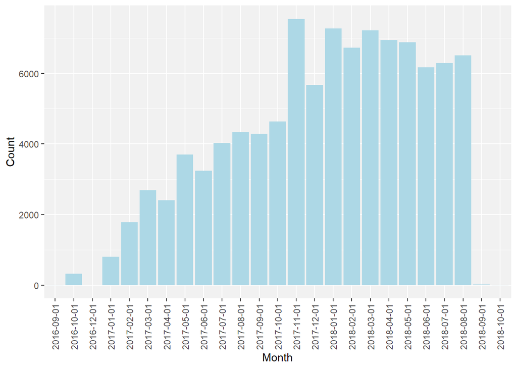

```r
ggplot(dfts, aes(ts.bym))+
  geom_bar(fill="lightblue")+
  theme(axis.text.x = element_text(angle=90, hjust=1, vjust=.5))+
  ylab("Count") +
  xlab("Month") +
  theme(panel.background = element_rect(fill = "#f1f1f1")) #最多銷售月份為2017-11-1
```

- 每日時段的訂單量

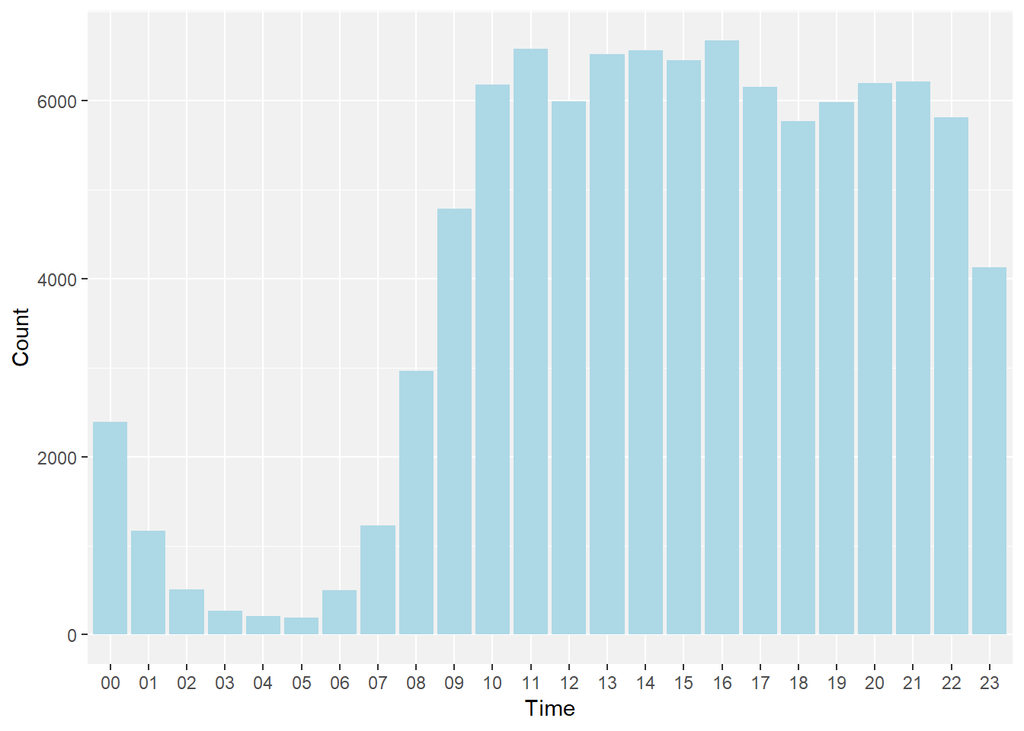

```r
ts.byH <- format(ts,format="%H") %>% data.frame()
ggplot(ts.byH ,aes(.))+
  geom_bar(fill="lightblue")+
  ylab("Count") +
  xlab("Time") +
  theme(panel.background = element_rect(fill = "#f1f1f1")) #中午到傍晚時段為下單尖峰
```

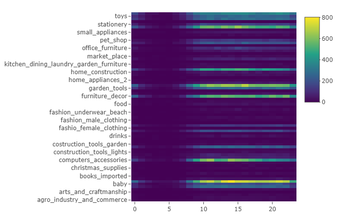

```r
##按照小時區分
DD.byh <- format(DD,format="%H")
D$byh <- DD.byh

#Rearranging data from D data frame
deaf = select(D, product_category_name_english,byh)
shook = group_by(deaf, byh, product_category_name_english) %>% summarise(n=n())
jump = spread(shook, byh, n)
jump[is.na(jump)] <- 0

#Converting product category column into rowname
jump = column_to_rownames(jump, loc = "product_category_name_english")
jump = as.matrix(jump)
#Using plot_ly () to draw the interactive heatmap
plot_ly(x=colnames(jump), y=rownames(jump), z = jump, type = "heatmap")
```

💡**1-2.賣家數量及地理分布**

```r
n_distinct(M_8$seller_id) #有2962位賣家
```

```
## [1] 2962
```

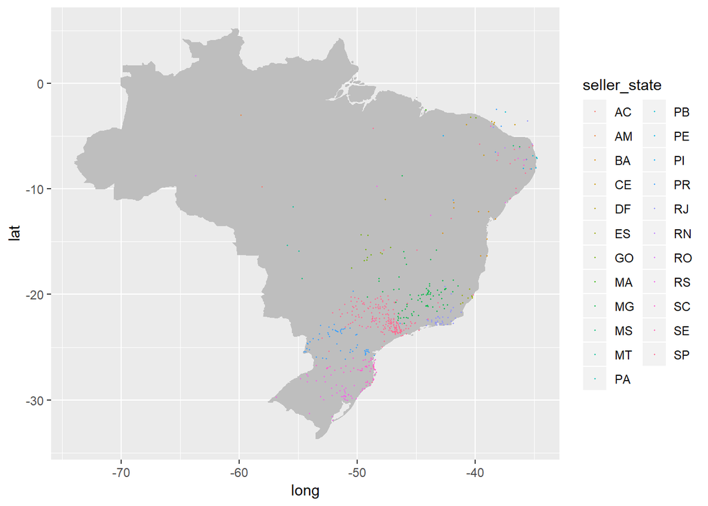

```r
ggplot() +
  geom_polygon(data = Brazil, aes(x=long, y = lat, group = group), fill="gray")+
  geom_point(data= M_8,aes(x=selllng,y=selllat,color=seller_state),size=0.2)
```

💡**1-3.買家數量及地理分布**

```r
n_distinct(M_8$customer_unique_id) #有92458位賣家
```

```
## [1] 92458
```

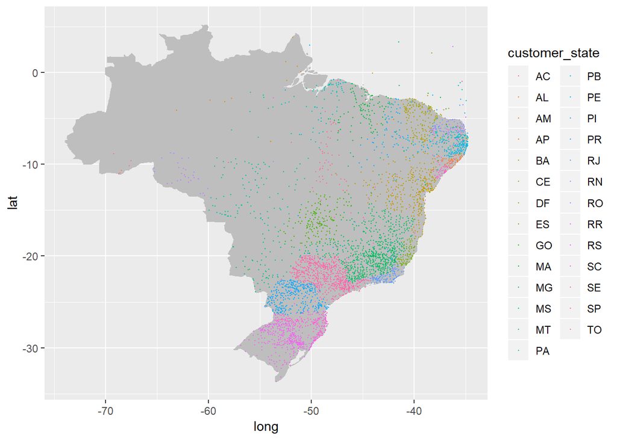

```r
ggplot() +
  geom_polygon(data = Brazil, aes(x=long, y = lat, group = group), fill="gray")+
  geom_point(data= M_8,aes(x=custlng,y=custlat,color=customer_state),size=0.2)
```

- 一次性顧客過多❗❗❗

```r
Q <- group_by(olist_customers_dataset.csv, customer_unique_id) %>% summarise(nid=n())
dim(Q) #共有96096名顧客
```

```
## [1] 96096     2
```

```r
table(Q$nid) %>% prop.table() %>% round(3) #一次性顧客佔所有顧客96.9%
```

```
##
##     1     2     3     4     5     6     7     9    17
## 0.969 0.029 0.002 0.000 0.000 0.000 0.000 0.000 0.000
```

```r
Q <- filter(Q, nid==1)
```

- 找一次性顧客的購買特性
  - 消費量最多為bed_beath_table
  - 消費額最多為health_beauty

```r
table(M_14_4$product_category_name_english) %>% sort() %>% tail()
```

```
##
##            housewares computers_accessories       furniture_decor
##                  6527                  7275                  7513
##        sports_leisure         health_beauty        bed_bath_table
##                  7954                  9103                 10001
```

```r
onece <- group_by(M_14_4, product_category_name_english) %>% summarise(mean=mean(price),sum=sum(price))
```

- 以一次性消費顧客最大消費額的health_beauty去分析其分布特性

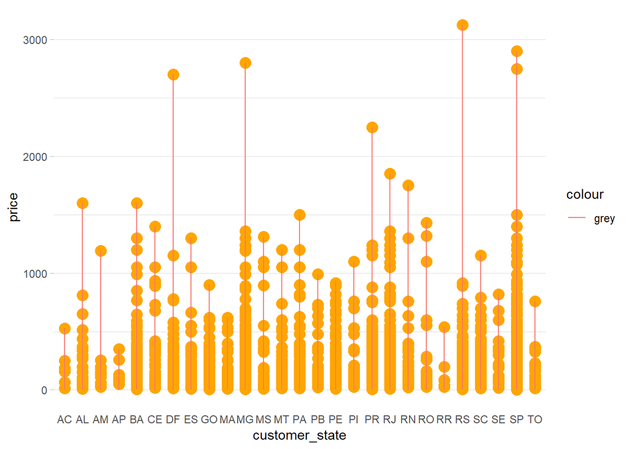

```r
health_beauty <- filter(M_14_4, product_category_name_english=="health_beauty")
ggplot(health_beauty, aes(x=customer_state, y=price,col="grey")) +
  geom_point(color="orange", size=4) +
  geom_segment( aes(x=customer_state, xend=customer_state, y=0, yend=price))+theme_light() +
  theme(
    panel.grid.major.x = element_blank(),
    panel.border = element_blank(),
    axis.ticks.x = element_blank()
  )
```

💡**1-4.產品類別銷售及地理區域市佔情形**

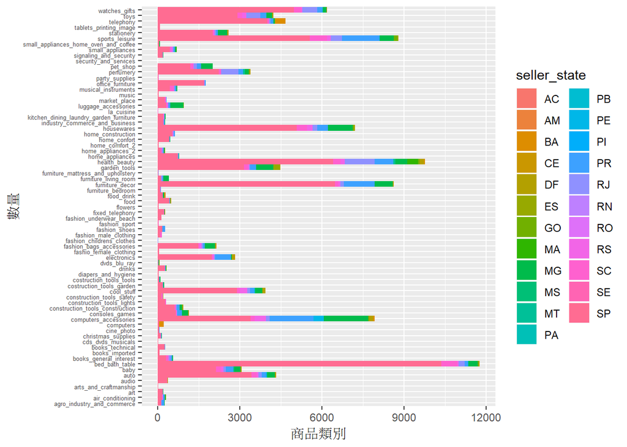

```r
ggplot() +
  geom_bar(data= M_8,aes(product_category_name_english,fill=seller_state),width=1)+
  coord_flip()+
  theme(axis.text.y = element_text( size=5))+
  ylab("商品類別") +
  xlab("數量")
```

- 互動式圓餅圖 : 不同商品類別的平均評分及銷量佔比
  - 商品種類後面的數字是其平均分數

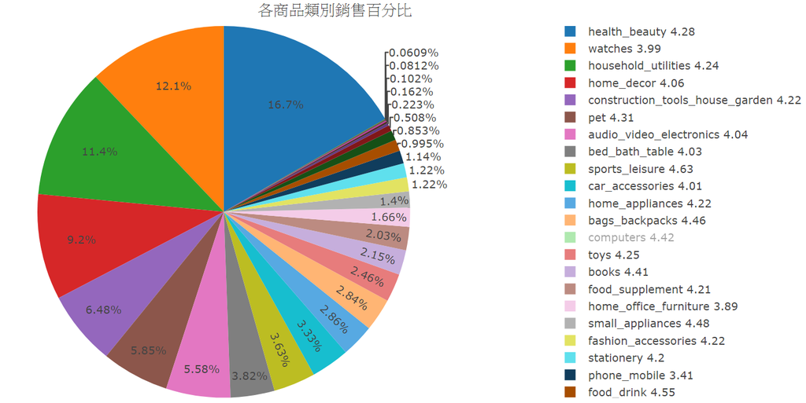

```r
Product2 <- group_by(M_15_3,business_segment)%>%summarize(score2=round(mean(review_score),2),percent=n()/nrow(M_15_3)*100)

plot_ly(Product2, labels = paste(Product2$business_segment,Product2$score2),values = Product2$percent, type = 'pie') %>%
  layout(title = '各商品類別銷售百分比',
         xaxis = list(showgrid = FALSE, zeroline = FALSE, showticklabels = FALSE),
         yaxis = list(showgrid = FALSE, zeroline = FALSE, showticklabels = FALSE))
```

### Part2:每年變化趨勢分析

💡**2-1.每月的訂單數，新進的買、賣家數趨勢變化**

- 併入Olist其他行銷資料

```r
marketingdata <- merge(closed[,c(1,2,6,8,9,12)],marketing[,c(1,4)],by = "mql_id")
M_9 <-  merge(M_8,marketingdata,by = "seller_id",all.x = T)
```

- 製作變數：每月的訂單數、“新進”的買賣家數

```r
M_9[,9]=as.POSIXct(M_9[,9], format="%Y-%m-%d")
M_9$time_group <- format(M_9$order_purchase_timestamp,"%Y%m") %>% as.numeric()
M_9$time <- format(M_9$order_purchase_timestamp,"%Y%m") %>% paste0(.,"28") %>% as.Date("%Y%m%d")

time_group <- unique(M_9$time_group) %>% sort()
num_seller_1 = sapply(1:length(time_group), # start by 2, so i-1 = 1
            function(i) setdiff(M_9$seller_id[M_9$time_group==time_group[i]],unique(M_9$seller_id[M_9$time_group<time_group[i]])) %>% length)
num_seller =  c(0,num_seller_1[-24])

num_customer_1 = sapply(1:length(time_group), # start by 2, so i-1 = 1
            function(i) setdiff(M_9$customer_unique_id[M_9$time_group==time_group[i]],unique(M_9$customer_unique_id[M_9$time_group<time_group[i]])) %>% length)
num_customer =  c(0,num_customer_1[-24])

num_order <- M_9 %>% group_by(time) %>% summarise(
  num_order = length(unique(order_id))
  )

plot <- cbind(time=(sort(unique(M_9$time))),num_seller,num_customer,num_order[,2])
```

- 畫出時間序列的折線圖

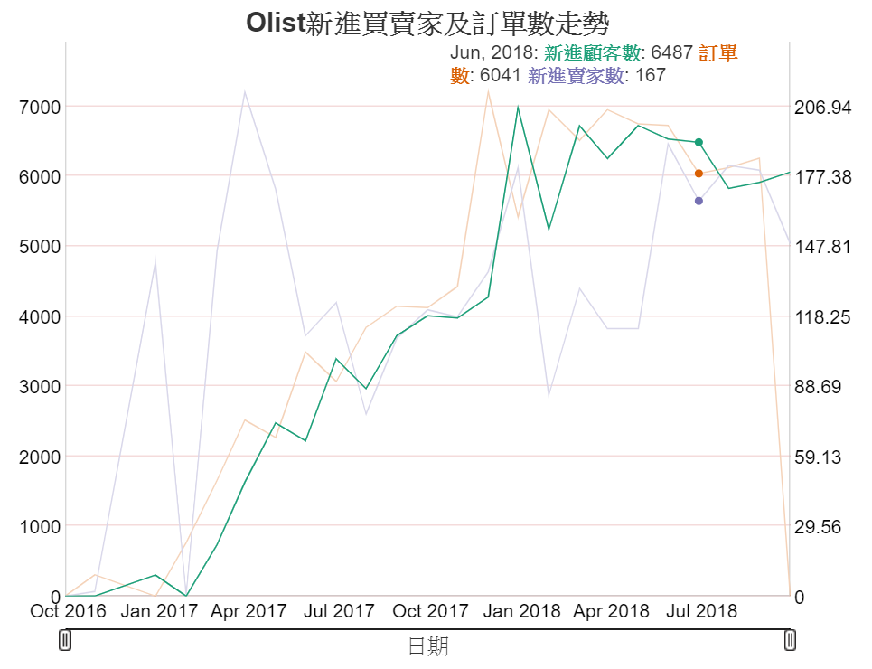

```r
data.ts<-zoo(plot,plot[,"time"])
plot <- data.ts[1:24,-1]

dygraph(plot,main = "Olist新進買賣家及訂單數走勢") %>%
   dySeries("num_customer", label = "新進顧客數")%>%
   dySeries("num_order", label = "訂單數") %>%
   dySeries("num_seller", axis = 'y2', label = "新進賣家數") %>%
   dyOptions( axisLineColor="orange",
    gridLineColor="indianred" , fillGraph = F,fillAlpha = 0.2,
    drawGrid  = TRUE,drawPoints=TRUE, pointSize = 1 ) %>%
   dyAxis("x", label = " 日期 ",   drawGrid = F) %>%
   dyAxis("y", label = " ", drawGrid = T) %>%
   dyHighlight(highlightCircleSize = 3,
    highlightSeriesBackgroundAlpha = 0.2) %>%
   dyOptions(colors = RColorBrewer::brewer.pal(3, 'Dark2')) %>%
   dyRangeSelector(height = 1)
```

💡**2-2.泡泡圖**

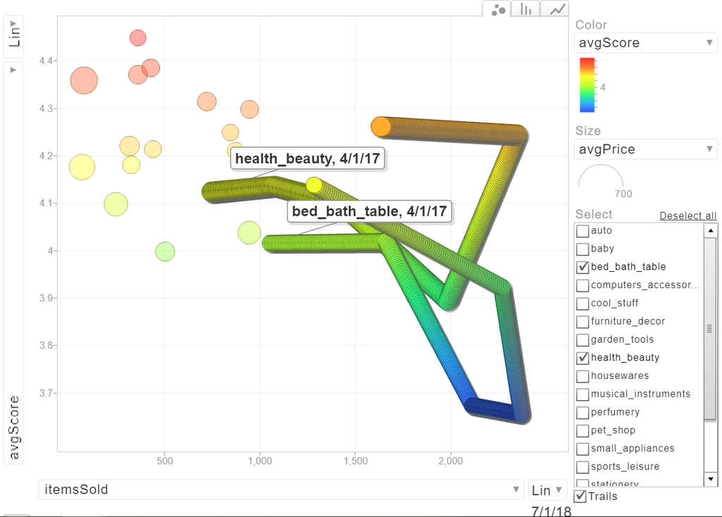

- 以一次性顧客消費量/金額最高的的兩個類別為例
  - 發現銷量跟評分呈負相關的現象

### Part3:地區下的銷售/評分情況

💡**3-1.地理區域和評分與銷售額的互動圖**

```r
#score: the average score of each city
score <- M_15_2 %>%
group_by(seller_city) %>%
  summarise(
  score = mean(review_score),
  pricesum = sum(price)+sum(freight_value)
  )
```

```r
#geolocation: private dataframe, with state,lon and lat of each city
geolocation <- olist_geolocation_dataset.csv
geolocation['seller_city'] = geo['geolocation_city']
geolocation['state'] = geo["geolocation_state"]
geolocation['geolocation_zip_code_prefix'] = NULL
geolocation <- geo %>%
group_by(geolocation_city) %>%
summarise(
  lat = mean(geolocation_lat),
  lng = mean(geolocation_lng),
  seller_city = geolocation_city[1],
  state = geolocation_state[1]
  )

#draw review of each state and use addPolygon to fig
city_score <- merge(score,geolocation,by="seller_city")
state_score <- city_score %>%
group_by(state) %>%
summarise(
  score = mean(score),
  pricesum = sum(pricesum)
)

#import Brazill json data
states <- geojsonio::geojson_read("C:\\Users\\User\\Desktop\\Group3\\midterm\\Brazil.json", what = "sp")

#color setting
bins_score <- c(0,1.0,2.0,3.0,4.0,5.0)
bins_money <- c(0,500,5000,10000,50000,100000,1000000,Inf)
pal_score <- colorBin("Blues", domain = state_score$score, bins = bins_score)
pal_money <- colorBin("Reds"  ,domain = state_score$pricesum, bins = bins_money)

#add score Info of State
labels <- sprintf(
  "<strong>%s</strong><br/> score: %g <br/> total price: %g ",
  state_score$state,
  state_score$score,
  state_score$pricesum
) %>% lapply(htmltools::HTML)
citylabels <- sprintf(
  "<strong>%s</strong><br/> score: %g <br/> total price: %g ",
  city_score$seller_city,
  city_score$score,
  city_score$pricesum
)%>% lapply(htmltools::HTML)

#form a map of Brazil
map_Brazil <- leaflet(states) %>%
  setView(lat=-22.074022, lng=-48.74026, zoom = 4) %>%
  addProviderTiles("MapBox", options = providerTileOptions(
    id = "mapbox.light",
    accessToken = Sys.getenv('MAPBOX_ACCESS_TOKEN')))
map_Brazil %>% addPolygons()

#draw city inform
map_Brazil <- map_Brazil %>%
  addCircleMarkers(
    lng     = city_score$lng,
    lat     = city_score$lat,
    label   = citylabels,
    weight  = .1,
    color   = "Yellow",
    labelOptions = labelOptions(
    style = list("font-weight" = "normal", padding = "3px 4px"),
    textsize = "15px",
    direction = "auto"),
    options = popupOptions(closeButton = TRUE),
    group = "city"
  )
```

- draw state labels

```r
map_Brazil <- map_Brazil %>%
#add state score information
addPolygons(
  fillColor = ~pal_score(state_score$score),
  weight = 2,
  opacity = 1,
  color = "white",
  dashArray = "3",
  fillOpacity = 0.7,
  highlight = highlightOptions(
    weight = 5,
    color = "#666",
    dashArray = "",
    fillOpacity = 0.7,
    bringToFront = TRUE),
  label = labels,
  labelOptions = labelOptions(
    style = list("font-weight" = "normal", padding = "3px 8px"),
    textsize = "15px",
    direction = "auto"),
  group = "state_score"
  )  %>%
#add state price information
  addPolygons(
  fillColor = ~pal_money(state_score$pricesum),
  weight = 2,
  opacity = 1,
  color = "white",
  dashArray = "3",
  fillOpacity = 0.7,
  highlight = highlightOptions(
    weight = 5,
    color = "#666",
    dashArray = "",
    fillOpacity = 0.7,
    bringToFront = TRUE),
  label = labels,
  labelOptions = labelOptions(
    style = list("font-weight" = "normal", padding = "3px 8px"),
    textsize = "15px",
    direction = "auto"),
  group = "state_price"
  ) %>%
# add layer Control
  addLayersControl(
    overlayGroups  = c("state_score","state_price","city")
  ) %>%
#add legens
addLegend(pal = pal_money, values = ~state_score$pricesum ,opacity =0.7,title = "price legend",
  position = "bottomleft" ) %>%
addLegend(pal = pal_score, values = ~state_score$score, opacity = 0.7, title = "score legend",
  position = "bottomleft")
```

- result

[figure not shown]

```r
map_Brazil
```

### Part4:評分迴歸模型

💡**4-1.對評分的回歸模型**

- 製作新變數及選擇變數

```r
score <- M_9[,c(5,10:12,16,17,19,20,22,24:29,32,38,46)] %>% group_by(order_id) %>% summarise(
  ship13 = mean(order_delivered_customer_date-order_approved_at),
  ship12 = mean(order_delivered_carrier_date-order_approved_at),
  ship23 = mean(order_delivered_customer_date-order_delivered_carrier_date),
  ship_ratio = mean(freight_value/price),
  price = sum(price),
  AVEvolume = sum(product_length_cm*product_height_cm*product_width_cm)/max(order_item_id),
  description = sum(product_description_lenght)/max(order_item_id),
  photo_num = sum(product_photos_qty)/max(order_item_id),
  pay_installment = sum(payment_installments)/max(order_item_id),
  dist = sum(distbtwn)/max(order_item_id),
  customer_state = customer_state[1],
  seller_state = seller_state[1],
  time_group = time_group[1]
)

reviews2 <- reviews %>% group_by(order_id) %>% summarise(
  score = mean(review_score)
)
```

- 建置對評分的回歸模型

```r
score_lm<-merge(score,reviews2,by="order_id")
score_lm[,2:4] <- sapply(score_lm[,2:4], as.numeric)
score_lm <- score_lm[complete.cases(score_lm),]
```

- 回歸結果

```r
model <- lm(score ~ . ,data = score_lm[,c(2:15)])
summary(model)
```

```
##
## Call:
## lm(formula = score ~ ., data = score_lm[, c(2:15)])
##
## Residuals:
##     Min      1Q  Median      3Q     Max
## -4.1415 -0.4159  0.5115  0.7576  8.7138
##
## Coefficients: (1 not defined because of singularities)
##                    Estimate Std. Error t value Pr(>|t|)
## (Intercept)       1.467e+02  1.667e+01   8.797  < 2e-16 ***
## ship13           -4.935e-02  5.077e-04 -97.207  < 2e-16 ***
## ship12           -5.992e-03  1.248e-03  -4.800 1.59e-06 ***
## ship23                   NA         NA      NA       NA
## ship_ratio       -1.026e-01  1.367e-02  -7.507 6.11e-14 ***
## price            -1.803e-04  1.989e-05  -9.068  < 2e-16 ***
## AVEvolume         5.964e-07  1.449e-07   4.117 3.85e-05 ***
## description       1.746e-05  5.592e-06   3.122  0.00180 **
## photo_num         3.931e-04  2.038e-03   0.193  0.84703
## pay_installment  -5.247e-03  1.555e-03  -3.374  0.00074 ***
## dist              2.896e-05  1.092e-05   2.653  0.00797 **
## customer_stateAL -3.049e-02  1.519e-01  -0.201  0.84094
## customer_stateAM  4.792e-01  1.722e-01   2.783  0.00539 **
## customer_stateAP  4.781e-01  2.030e-01   2.355  0.01853 *
## customer_stateBA -2.006e-01  1.407e-01  -1.426  0.15385
## customer_stateCE -8.222e-02  1.431e-01  -0.574  0.56564
## customer_stateDF -3.121e-01  1.417e-01  -2.203  0.02757 *
## customer_stateES -2.290e-01  1.419e-01  -1.614  0.10651
## customer_stateGO -2.120e-01  1.419e-01  -1.493  0.13534
## customer_stateMA -1.838e-01  1.464e-01  -1.256  0.20923
## customer_stateMG -3.013e-01  1.398e-01  -2.156  0.03113 *
## customer_stateMS -1.398e-01  1.465e-01  -0.954  0.33986
## customer_stateMT -4.708e-02  1.452e-01  -0.324  0.74583
## customer_statePA -5.394e-03  1.447e-01  -0.037  0.97025
## customer_statePB -1.621e-02  1.490e-01  -0.109  0.91339
## customer_statePE -8.902e-02  1.423e-01  -0.626  0.53158
## customer_statePI -1.089e-01  1.500e-01  -0.726  0.46804
## customer_statePR -2.555e-01  1.404e-01  -1.819  0.06889 .
## customer_stateRJ -3.674e-01  1.397e-01  -2.629  0.00856 **
## customer_stateRN  2.469e-02  1.502e-01   0.164  0.86945
```

[output cut: 20 more lines]

```
## seller_statePR    3.045e-01  6.999e-01   0.435  0.66350
## seller_stateRJ    2.887e-01  7.001e-01   0.412  0.68003
## seller_stateRN    1.840e-01  7.205e-01   0.255  0.79847
## seller_stateRO    4.848e-02  8.568e-01   0.057  0.95487
## seller_stateRS    3.207e-01  7.003e-01   0.458  0.64697
## seller_stateSC    3.108e-01  7.001e-01   0.444  0.65708
## seller_stateSE   -3.641e-01  8.204e-01  -0.444  0.65721
## seller_stateSP    1.824e-01  6.998e-01   0.261  0.79432
## time_group       -7.028e-04  8.259e-05  -8.510  < 2e-16 ***
## ---
## Signif. codes:  0 '***' 0.001 '**' 0.01 '*' 0.05 '.' 0.1 ' ' 1
##
## Residual standard error: 1.211 on 93393 degrees of freedom
## Multiple R-squared:  0.1247, Adjusted R-squared:  0.1242
## F-statistic: 233.4 on 57 and 93393 DF,  p-value: < 2.2e-16
```

💡**4-2.相關係數**

- 相關係數視覺化

```r
cor(score_lm[,c(2:11,14,15)])
```

```
##                       ship13       ship12       ship23  ship_ratio
## ship13           1.000000000  0.386467622  0.928326482  0.07662941
## ship12           0.386467622  1.000000000  0.015887260 -0.02122266
## ship23           0.928326482  0.015887260  1.000000000  0.09162889
## ship_ratio       0.076629410 -0.021222657  0.091628893  1.00000000
## price            0.048197974  0.066818713  0.025318109 -0.27239650
## AVEvolume        0.062146732  0.118137527  0.019754219 -0.08065473
## description      0.005079196  0.005716356  0.003202211 -0.11409592
## photo_num       -0.022481239 -0.035293149 -0.010145917 -0.04701655
## pay_installment  0.074208135  0.057819481  0.057143319 -0.18573847
## dist             0.267048036  0.008095524  0.286245083  0.14047168
## time_group      -0.059746756 -0.080666577 -0.032256348  0.00938864
## score           -0.336192046 -0.154493835 -0.302193607 -0.02709736
##                        price   AVEvolume  description   photo_num
## ship13           0.048197974  0.06214673  0.005079196 -0.02248124
## ship12           0.066818713  0.11813753  0.005716356 -0.03529315
## ship23           0.025318109  0.01975422  0.003202211 -0.01014592
## ship_ratio      -0.272396502 -0.08065473 -0.114095916 -0.04701655
## price            1.000000000  0.30940086  0.267643426  0.11663583
## AVEvolume        0.309400865  1.00000000  0.115844242  0.10944865
## description      0.267643426  0.11584424  1.000000000  0.22384301
## photo_num        0.116635834  0.10944865  0.223843009  1.00000000
## pay_installment  0.316193547  0.17100803  0.074115328  0.03766222
## dist             0.112570130  0.05975062  0.139228914  0.11028820
## time_group      -0.004081408 -0.03937762  0.022193502 -0.01354552
## score           -0.031142695 -0.01878400  0.011170128  0.01252416
##                 pay_installment         dist   time_group        score
## ship13               0.07420813  0.267048036 -0.059746756 -0.336192046
## ship12               0.05781948  0.008095524 -0.080666577 -0.154493835
## ship23               0.05714332  0.286245083 -0.032256348 -0.302193607
## ship_ratio          -0.18573847  0.140471682  0.009388640 -0.027097359
## price                0.31619355  0.112570130 -0.004081408 -0.031142695
## AVEvolume            0.17100803  0.059750624 -0.039377624 -0.018784003
## description          0.07411533  0.139228914  0.022193502  0.011170128
## photo_num            0.03766222  0.110288200 -0.013545517  0.012524155
## pay_installment      1.00000000  0.087421435 -0.060023291 -0.030452988
## dist                 0.08742144  1.000000000 -0.035967577 -0.038081568
## time_group          -0.06002329 -0.035967577  1.000000000 -0.007807136
## score               -0.03045299 -0.038081568 -0.007807136  1.000000000
```

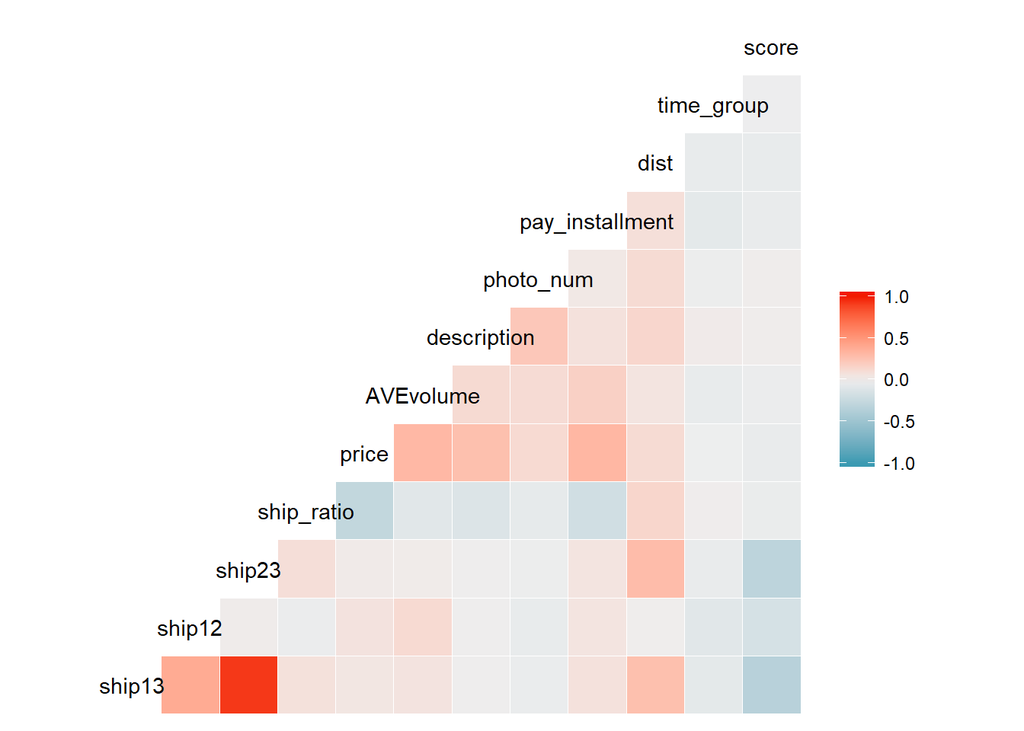

```r
ggcorr(score_lm[,c(2:11,14,15)], method = c("everything", "pearson"))
```